# Government Employment Figures by Region

The data set is available from the website [LMIP Gov AU](http://lmip.gov.au/default.aspx?LMIP/Downloads/ABSLabourForceRegion).

It contains regional figures for population counts of employment per industry.

```r
data <- read.csv("data/employment/SA4_regions_feb2017.csv", header=TRUE)
# need to fix the numbers
for(i in 4:9) {
  data[,i] <- as.numeric(gsub(",", "", data[,i]))
}
head(data)
```

|  | Employment.Region | State.Territory | Industry | Employment.by.Industry...Total | Employed.Full.Time | Employed.Part.Time | Employed...Male | Employed...Female | Five.year.growth.by.Industry | Employment.Distribution.... |
| --- | --- | --- | --- | --- | --- | --- | --- | --- | --- | --- |
| 1 | Capital Region | NSW/ACT | Agriculture, Forestry and Fishing | 7200 | 5100 | 2100 | 5800 | 1300 | -4300 | 2.2 |
| 2 | Capital Region | NSW/ACT | Mining | 800 | 800 | 0 | 500 | 300 | 300 | 0.2 |
| 3 | Capital Region | NSW/ACT | Manufacturing | 9500 | 7900 | 1600 | 7500 | 2000 | -1800 | 3.0 |
| 4 | Capital Region | NSW/ACT | Electricity, Gas, Water and Waste Services | 2500 | 2500 | 0 | 2200 | 300 | -400 | 0.8 |
| 5 | Capital Region | NSW/ACT | Construction | 24400 | 21900 | 2500 | 22600 | 1800 | -500 | 7.6 |
| 6 | Capital Region | NSW/ACT | Wholesale Trade | 4000 | 3000 | 1000 | 2800 | 1200 | -1200 | 1.2 |

```r
str(data)
```

```
'data.frame':   836 obs. of  10 variables:
 $ Employment.Region             : Factor w/ 44 levels "Adelaide North",..: 9 9 9 9 9 9 9 9 9 9 ...
 $ State.Territory               : Factor w/ 9 levels "","NSW","NSW/ACT",..: 3 3 3 3 3 3 3 3 3 3 ...
 $ Industry                      : Factor w/ 19 levels "Accommodation and Food Services",..: 3 12 11 7 5 19 17 1 18 10 ...
 $ Employment.by.Industry...Total: num  7200 800 9500 2500 24400 4000 24700 22500 11800 3800 ...
 $ Employed.Full.Time            : num  5100 800 7900 2500 21900 3000 12000 8000 9100 3000 ...
 $ Employed.Part.Time            : num  2100 0 1600 0 2500 1000 12700 14600 2700 800 ...
 $ Employed...Male               : num  5800 500 7500 2200 22600 2800 10800 11200 9800 2100 ...
 $ Employed...Female             : num  1300 300 2000 300 1800 1200 14000 11400 1900 1700 ...
 $ Five.year.growth.by.Industry  : num  -4300 300 -1800 -400 -500 -1200 1100 1900 1900 -2700 ...
 $ Employment.Distribution....   : num  2.2 0.2 3 0.8 7.6 1.2 7.7 7 3.7 1.2 ...
```

Initially we will investigate the industry by region, the field of interest is the employment by industry total. The data is currently in long format we need to convert it to wide format.

```r
data1 <- data[,c(1:4)]
colnames(data1) <- c("Region", "State", "Industry", "TotalCount")
data1 <- data1[data1$Region != "Australia",]
head(data1)
```

|  | Region | State | Industry | TotalCount |
| --- | --- | --- | --- | --- |
| 1 | Capital Region | NSW/ACT | Agriculture, Forestry and Fishing | 7200 |
| 2 | Capital Region | NSW/ACT | Mining | 800 |
| 3 | Capital Region | NSW/ACT | Manufacturing | 9500 |
| 4 | Capital Region | NSW/ACT | Electricity, Gas, Water and Waste Services | 2500 |
| 5 | Capital Region | NSW/ACT | Construction | 24400 |
| 6 | Capital Region | NSW/ACT | Wholesale Trade | 4000 |

```r
temp <- reshape(data1, idvar=c("Region", "State"), timevar=c("Industry"), direction="wide")
temp$Location <- paste(temp$State, temp$Region, sep=" ")
head(temp)
```

|  | Region | State | TotalCount.Agriculture, Forestry and Fishing | TotalCount.Mining | TotalCount.Manufacturing | TotalCount.Electricity, Gas, Water and Waste Services | TotalCount.Construction | TotalCount.Wholesale Trade | TotalCount.Retail Trade | TotalCount.Accommodation and Food Services | TotalCount.Transport, Postal and Warehousing | TotalCount.Information Media and Telecommunications | TotalCount.Financial and Insurance Services | TotalCount.Rental, Hiring and Real Estate Services | TotalCount.Professional, Scientific and Technical Services | TotalCount.Administrative and Support Services | TotalCount.Public Administration and Safety | TotalCount.Education and Training | TotalCount.Health Care and Social Assistance | TotalCount.Arts and Recreation Services | TotalCount.Other Services | Location |
| --- | --- | --- | --- | --- | --- | --- | --- | --- | --- | --- | --- | --- | --- | --- | --- | --- | --- | --- | --- | --- | --- | --- |
| 1 | Capital Region | NSW/ACT | 7200 | 800 | 9500 | 2500 | 24400 | 4000 | 24700 | 22500 | 11800 | 3800 | 5900 | 4600 | 33500 | 9100 | 77200 | 23600 | 36400 | 8000 | 10700 | NSW/ACT Capital Region |
| 20 | Central West | NSW | 11700 | 8200 | 5200 | 2600 | 7800 | 2900 | 9900 | 5600 | 3800 | 400 | 2400 | 500 | 4300 | 1300 | 7900 | 8200 | 15800 | 1800 | 5300 | NSW Central West |
| 39 | Far West Orana | NSW | 10500 | 1300 | 2600 | 400 | 4500 | 1700 | 6900 | 5000 | 500 | 0 | 1300 | 0 | 600 | 2300 | 3600 | 6100 | 7700 | 600 | 2800 | NSW Far West Orana |
| 58 | Hunter | NSW | 7200 | 17200 | 20900 | 4700 | 30100 | 7100 | 30700 | 28000 | 13500 | 2800 | 9800 | 4000 | 18000 | 12200 | 17400 | 26700 | 45600 | 6800 | 13600 | NSW Hunter |
| 77 | Illawarra South Coast | NSW | 400 | 2900 | 13000 | 1800 | 22700 | 3100 | 23300 | 16800 | 10500 | 2900 | 5400 | 3500 | 10700 | 7600 | 10900 | 23000 | 32600 | 2700 | 5800 | NSW Illawarra South Coast |
| 96 | Mid North Coast | NSW | 9500 | 400 | 6600 | 2800 | 16100 | 3300 | 21500 | 14000 | 4000 | 700 | 1700 | 1900 | 8500 | 4600 | 11300 | 13100 | 24600 | 1400 | 6500 | NSW Mid North Coast |

```r
names(temp)
```

```
 [1] "Region"
 [2] "State"
 [3] "TotalCount.Agriculture, Forestry and Fishing"
 [4] "TotalCount.Mining"
 [5] "TotalCount.Manufacturing"
 [6] "TotalCount.Electricity, Gas, Water and Waste Services"
 [7] "TotalCount.Construction"
 [8] "TotalCount.Wholesale Trade"
 [9] "TotalCount.Retail Trade"
[10] "TotalCount.Accommodation and Food Services"
[11] "TotalCount.Transport, Postal and Warehousing"
[12] "TotalCount.Information Media and Telecommunications"
[13] "TotalCount.Financial and Insurance Services"
[14] "TotalCount.Rental, Hiring and Real Estate Services"
[15] "TotalCount.Professional, Scientific and Technical Services"
[16] "TotalCount.Administrative and Support Services"
[17] "TotalCount.Public Administration and Safety"
[18] "TotalCount.Education and Training"
[19] "TotalCount.Health Care and Social Assistance"
[20] "TotalCount.Arts and Recreation Services"
[21] "TotalCount.Other Services"
[22] "Location"
```

```r
colnames(temp) <- c("Region",
                 "State",
                 "AGRIC_FRST_FISH",
                 "MINING",
                 "MANUF",
                 "UTILITIES",
                 "CONSTR",
                 "WSALE_TRADE",
                 "RETAIL_TRADE",
                 "ACC_FOOD_SRV",
                 "TRNS_POST_WHOUSE",
                 "INFO_MEDIA_TELEC",
                 "FIN_INS_SRV",
                 "RENT_HIRE_RE_SRV",
                 "PROF_SCI_TECH_SRV",
                 "ADM_SUP_SRV",
                 "PADMIN_SAFETY",
                 "EDU_TRAIN",
                 "HEALTH_SOC_ASSIST",
                 "ARTS_REC_SRV",
                 "OTHER_SRV",
                 "Location")
df1 <- data.frame(Location=temp$Location,
                  temp[,4:ncol(temp)-1])
head(df1)
```

|  | Location | AGRIC_FRST_FISH | MINING | MANUF | UTILITIES | CONSTR | WSALE_TRADE | RETAIL_TRADE | ACC_FOOD_SRV | TRNS_POST_WHOUSE | INFO_MEDIA_TELEC | FIN_INS_SRV | RENT_HIRE_RE_SRV | PROF_SCI_TECH_SRV | ADM_SUP_SRV | PADMIN_SAFETY | EDU_TRAIN | HEALTH_SOC_ASSIST | ARTS_REC_SRV | OTHER_SRV |
| --- | --- | --- | --- | --- | --- | --- | --- | --- | --- | --- | --- | --- | --- | --- | --- | --- | --- | --- | --- | --- |
| 1 | NSW/ACT Capital Region | 7200 | 800 | 9500 | 2500 | 24400 | 4000 | 24700 | 22500 | 11800 | 3800 | 5900 | 4600 | 33500 | 9100 | 77200 | 23600 | 36400 | 8000 | 10700 |
| 20 | NSW Central West | 11700 | 8200 | 5200 | 2600 | 7800 | 2900 | 9900 | 5600 | 3800 | 400 | 2400 | 500 | 4300 | 1300 | 7900 | 8200 | 15800 | 1800 | 5300 |
| 39 | NSW Far West Orana | 10500 | 1300 | 2600 | 400 | 4500 | 1700 | 6900 | 5000 | 500 | 0 | 1300 | 0 | 600 | 2300 | 3600 | 6100 | 7700 | 600 | 2800 |
| 58 | NSW Hunter | 7200 | 17200 | 20900 | 4700 | 30100 | 7100 | 30700 | 28000 | 13500 | 2800 | 9800 | 4000 | 18000 | 12200 | 17400 | 26700 | 45600 | 6800 | 13600 |
| 77 | NSW Illawarra South Coast | 400 | 2900 | 13000 | 1800 | 22700 | 3100 | 23300 | 16800 | 10500 | 2900 | 5400 | 3500 | 10700 | 7600 | 10900 | 23000 | 32600 | 2700 | 5800 |
| 96 | NSW Mid North Coast | 9500 | 400 | 6600 | 2800 | 16100 | 3300 | 21500 | 14000 | 4000 | 700 | 1700 | 1900 | 8500 | 4600 | 11300 | 13100 | 24600 | 1400 | 6500 |

Looking initially at the data we can check if it is multivariate normal,

```
   Mardia's Multivariate Normality Test
---------------------------------------
   data : X

   g1p            : 285.222
   chi.skew       : 2044.091
   p.value.skew   : 3.269859e-33

   g2p            : 456.9211
   z.kurtosis     : 6.722636
   p.value.kurt   : 1.784661e-11

   chi.small.skew : 2201.714
   p.value.small  : 4.51671e-46

   Result          : Data are not multivariate normal.
---------------------------------------
```

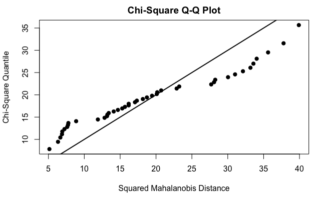

```r
require(MVN)
X <- df1[,2:ncol(df1)]
X <- scale(X)
mardiaTest(X, qqplot=TRUE)
```

```r
hzTest(X)
```

```
  Henze-Zirkler's Multivariate Normality Test
---------------------------------------------
  data : X

  HZ      : 1.026877
  p-value : 0

  Result  : Data are not multivariate normal.
---------------------------------------------
```

```r
roystonTest(X)
```

```
  Royston's Multivariate Normality Test
---------------------------------------------
  data : X

  H       : 68.46346
  p-value : 1.764763e-14

  Result  : Data are not multivariate normal.
---------------------------------------------
```

The test results suggest that the data is not multivariate normal, and this is also reinforced by the qqplot. However we can still perform ordination and some analysis.

Initially inspecting the data through principle components.

```r
row.names(X) <- df1$Location
df1.prcomp <- princomp(X, cor=TRUE)
df1.prcomp
```

```
Call:
princomp(x = X, cor = TRUE)

Standard deviations:
    Comp.1     Comp.2     Comp.3     Comp.4     Comp.5     Comp.6     Comp.7     Comp.8
3.88669332 1.09781697 0.92408420 0.82408389 0.68134731 0.50312674 0.35455678 0.31044448
    Comp.9    Comp.10    Comp.11    Comp.12    Comp.13    Comp.14    Comp.15    Comp.16
0.26588623 0.18540309 0.17999963 0.15488755 0.12072621 0.10609013 0.10174910 0.08643939
   Comp.17    Comp.18    Comp.19
0.07003998 0.06000035 0.04785478

 19  variables and  43 observations.
```

```r
df1.prcomp$loadings
```

```
Loadings:
                  Comp.1 Comp.2 Comp.3 Comp.4 Comp.5 Comp.6 Comp.7 Comp.8 Comp.9
AGRIC_FRST_FISH    0.124         0.818 -0.501  0.160 -0.155
MINING                   -0.830  0.115  0.307 -0.208 -0.286         0.174
MANUF             -0.222        -0.251 -0.502               -0.177  0.190  0.380
UTILITIES         -0.224 -0.302        -0.167         0.554 -0.159 -0.264 -0.591
CONSTR            -0.245 -0.126 -0.120 -0.163        -0.111  0.378  0.200 -0.178
WSALE_TRADE       -0.247               -0.243 -0.132        -0.211  0.356
RETAIL_TRADE      -0.254                                     0.104 -0.122  0.301
ACC_FOOD_SRV      -0.250         0.131  0.101                0.208 -0.386  0.363
TRNS_POST_WHOUSE  -0.228        -0.266 -0.209        -0.587 -0.193 -0.516 -0.184
INFO_MEDIA_TELEC  -0.239  0.256  0.145  0.115 -0.191        -0.176
FIN_INS_SRV       -0.238  0.234  0.159        -0.203 -0.233 -0.169  0.105 -0.262
RENT_HIRE_RE_SRV  -0.244  0.126         0.148        -0.143  0.591        -0.186
PROF_SCI_TECH_SRV -0.241  0.163  0.215  0.215               -0.221  0.216 -0.158
ADM_SUP_SRV       -0.254                                     0.133         0.105
PADMIN_SAFETY     -0.197                0.224  0.895 -0.102 -0.117  0.207
EDU_TRAIN         -0.252                              0.212         0.128  0.127
HEALTH_SOC_ASSIST -0.253                              0.238  0.165
ARTS_REC_SRV      -0.244         0.173  0.216         0.120 -0.328 -0.347  0.233
OTHER_SRV         -0.248 -0.164        -0.179                0.174  0.112
                  Comp.10 Comp.11 Comp.12 Comp.13 Comp.14 Comp.15 Comp.16 Comp.17
AGRIC_FRST_FISH
MINING
MANUF                      0.308          -0.207  -0.259          -0.396
UTILITIES                  0.102                          -0.125           0.155
CONSTR             0.243  -0.668                  -0.326          -0.105
WSALE_TRADE        0.212           0.221   0.259          -0.170   0.489   0.110
RETAIL_TRADE      -0.120  -0.220  -0.155  -0.212   0.232  -0.710   0.202
ACC_FOOD_SRV                               0.629  -0.255          -0.138   0.293
TRNS_POST_WHOUSE  -0.252                                                  -0.118
INFO_MEDIA_TELEC   0.329          -0.265           0.171  -0.217  -0.524  -0.161
FIN_INS_SRV       -0.224          -0.260   0.159           0.113  -0.121   0.147
RENT_HIRE_RE_SRV           0.410   0.383  -0.329                           0.119
PROF_SCI_TECH_SRV          0.110   0.257          -0.146  -0.136   0.138
ADM_SUP_SRV                0.153  -0.620  -0.317  -0.132   0.347   0.415   0.149
PADMIN_SAFETY
EDU_TRAIN         -0.441  -0.341   0.248  -0.127   0.380   0.304           0.373
HEALTH_SOC_ASSIST -0.444                   0.160  -0.129                  -0.743
ARTS_REC_SRV       0.399  -0.131   0.300  -0.254           0.260   0.128  -0.239
```

[output cut: 15 more lines]

```
ADM_SUP_SRV        0.229
PADMIN_SAFETY
EDU_TRAIN          0.184  -0.191
HEALTH_SOC_ASSIST         -0.179
ARTS_REC_SRV      -0.297
OTHER_SRV                  0.290

               Comp.1 Comp.2 Comp.3 Comp.4 Comp.5 Comp.6 Comp.7 Comp.8 Comp.9 Comp.10
SS loadings     1.000  1.000  1.000  1.000  1.000  1.000  1.000  1.000  1.000   1.000
Proportion Var  0.053  0.053  0.053  0.053  0.053  0.053  0.053  0.053  0.053   0.053
Cumulative Var  0.053  0.105  0.158  0.211  0.263  0.316  0.368  0.421  0.474   0.526
               Comp.11 Comp.12 Comp.13 Comp.14 Comp.15 Comp.16 Comp.17 Comp.18 Comp.19
SS loadings      1.000   1.000   1.000   1.000   1.000   1.000   1.000   1.000   1.000
Proportion Var   0.053   0.053   0.053   0.053   0.053   0.053   0.053   0.053   0.053
Cumulative Var   0.579   0.632   0.684   0.737   0.789   0.842   0.895   0.947   1.000
```

```r
df1.prcomp$var <- df1.prcomp$sdev^2
```

The amount of variance explained per component

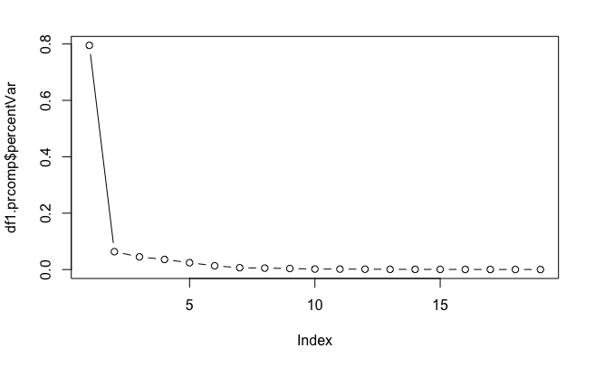

```r
total <- sum(df1.prcomp$var)
df1.prcomp$percentVar <- df1.prcomp$var / total
plot(df1.prcomp$percentVar, type="b")
```

```r
data.frame(component=1:length(df1.prcomp$var), variance=df1.prcomp$var, percent=round(df1.prcomp$percentVar, 4))
```

|  | component | variance | percent |
| --- | --- | --- | --- |
| Comp.1 | 1 | 15.106384947 | 0.7951 |
| Comp.2 | 2 | 1.205202104 | 0.0634 |
| Comp.3 | 3 | 0.853931608 | 0.0449 |
| Comp.4 | 4 | 0.679114257 | 0.0357 |
| Comp.5 | 5 | 0.464234160 | 0.0244 |
| Comp.6 | 6 | 0.253136518 | 0.0133 |
| Comp.7 | 7 | 0.125710513 | 0.0066 |
| Comp.8 | 8 | 0.096375778 | 0.0051 |
| Comp.9 | 9 | 0.070695489 | 0.0037 |
| Comp.10 | 10 | 0.034374305 | 0.0018 |

[output cut: 9 more lines]

Printing the biplot for industries, there are a large number of regions hence we can move the viewport in order to get a better view of the ordination.

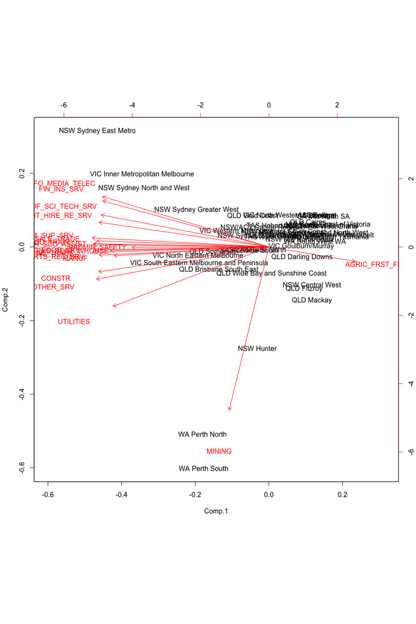

```r
biplot(df1.prcomp, choices=c(1,2))
```

While the 1st component provides the most variation explained, it is difficult to visualise, the 2nd and 3rd components provide a separate axes which permits some simplication in the visualisation.

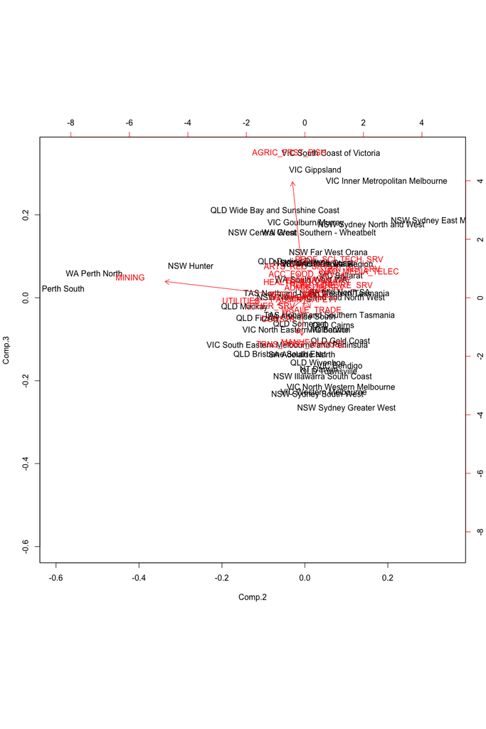

```r
biplot(df1.prcomp, choices=c(2,3), expand=1)
```

Each segment of the axes is drawn separately in the series below.

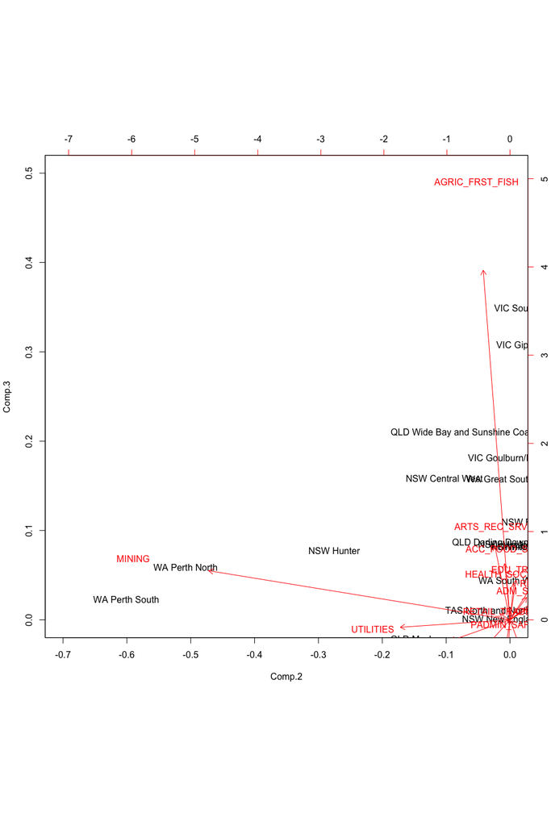

```r
biplot(df1.prcomp, choices=c(2,3), expand=1.4, xlim=c(-0.7, 0.0), ylim=c(0.0, 0.5))
```

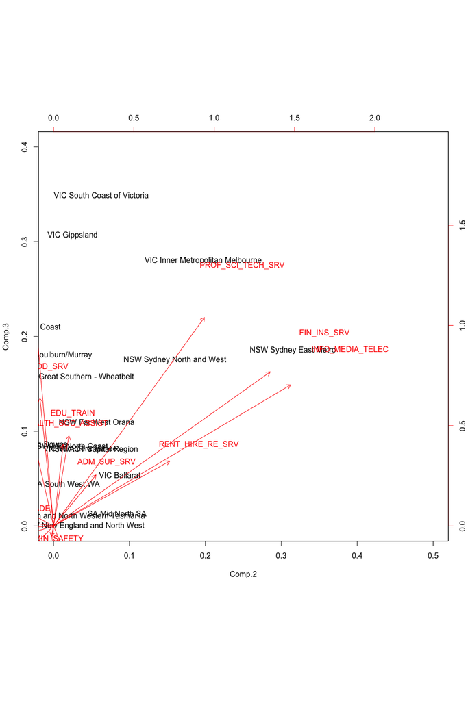

```r
biplot(df1.prcomp, choices=c(2,3), expand=3, xlim=c(0.0, 0.5), ylim=c(0.0, 0.4))
```

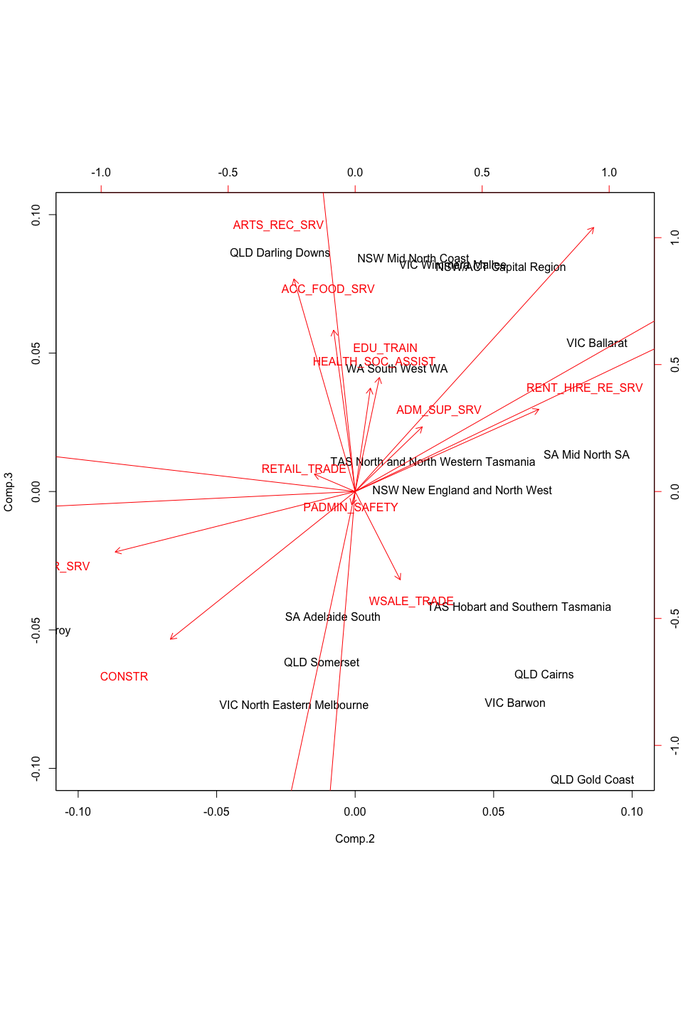

```r
biplot(df1.prcomp, choices=c(2,3), expand=1.3, xlim=c(-0.1, 0.1), ylim=c(-0.1, 0.1))
```

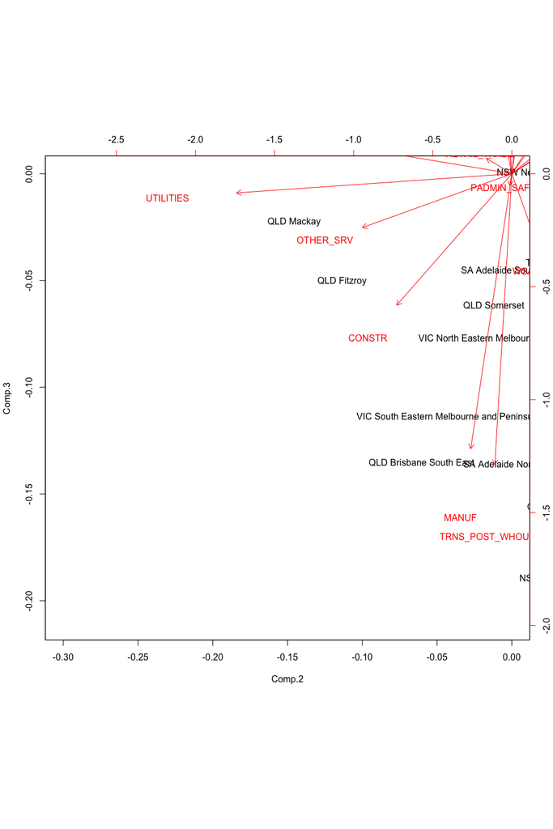

```r
biplot(df1.prcomp, choices=c(2,3), expand=1.5, xlim=c(-0.3, 0.0), ylim=c(-0.21, 0.0))
```

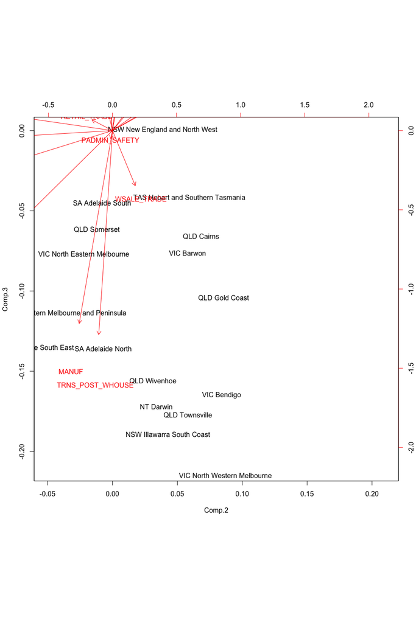

```r
biplot(df1.prcomp, choices=c(2,3), expand=1.4, xlim=c(-0.05, 0.21), ylim=c(-0.21, 0.0))
```